# Introduction to ggplot for Visualization

## Legends

You can alter the position or existence of legends. Positions include “top, bottom, left, right, and none”.

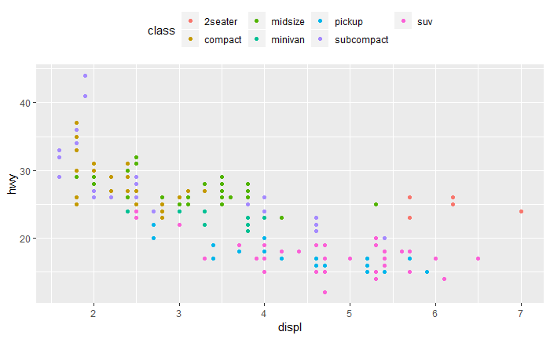

```r
hwy_plot +
  theme(legend.position = "top")
```

You can control other aspects of the legend’s appearance as well. Here we control the number of rows displayed with `guide_legend(nrow =1)`

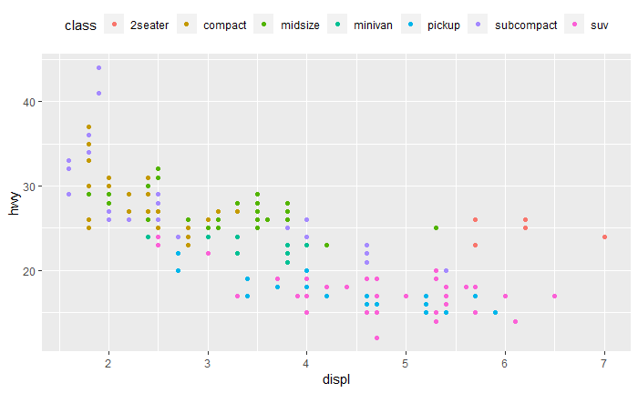

```r
hwy_plot +
  theme(legend.position = "top") +
  guides(color = guide_legend(nrow = 1))
```

## Labels: Axis / Markers / Ticks

### Titles, subtiles, and captions

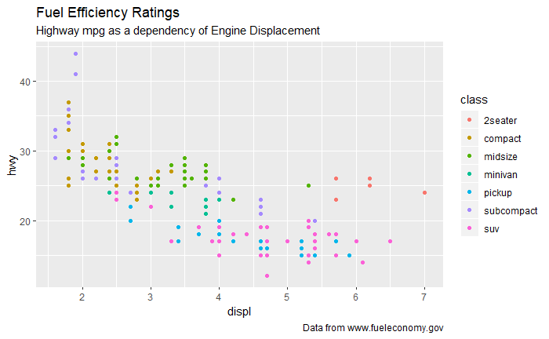

```r
hwy_plot +
  labs(
    title = "Fuel Efficiency Ratings",
    subtitle = "Highway mpg as a dependency of Engine Displacement",
    caption = "Data from www.fueleconomy.gov"
  )
```

### Axis & legend titles

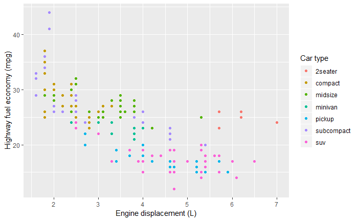

```r
hwy_plot +
  labs(
    x = "Engine displacement (L)",
    y = "Highway fuel economy (mpg)",
    colour = "Car type"
    )
```

### Axis ticks & breaks

Suppose you want the y axis to be listed in increments of 5 rather than the default. See below. **Alternatively, remove the axis lables** with code such as:

- `scale_x_continuous(labels = NULL)`
- `scale_y_continuous(labels = NULL)`

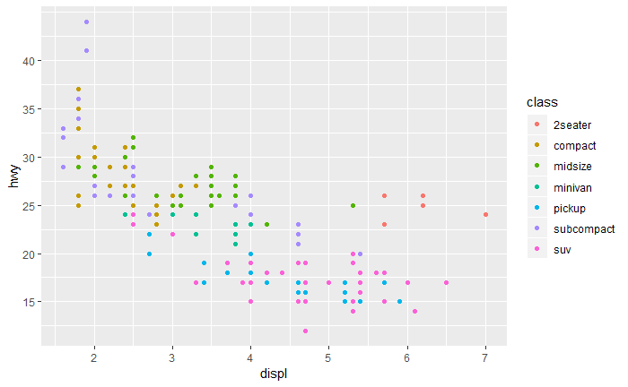

```r
hwy_plot +
  scale_y_continuous(breaks = seq(15, 40, by = 5))
```

## Annotations

While Annotations can help you highlight your data story, the execution of the annotation is a bit persnickety. *R4DS* recommends the following approach which accommodates requirements for the same x & y variables. This requirement for sameness in data frame will help draw axes scales within expected limits. Follow the format presented here and read the explanation in the *R4DS* book as you experiment with Annotations.

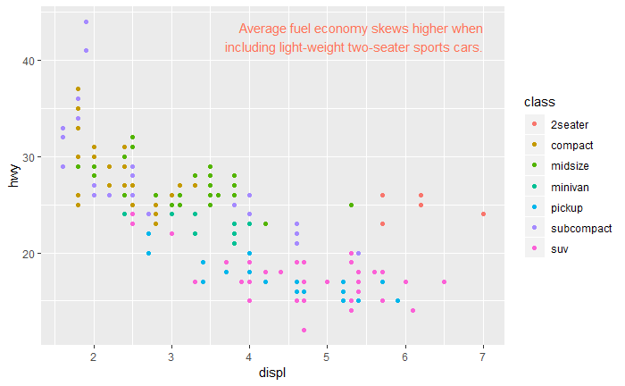

```r
annotation <- mpg %>%
  summarise(
    displ = max(displ),
    hwy = max(hwy),
    label_text = "Average fuel economy skews higher when\nincluding light-weight two-seater sports cars."
  )
ggplot(data = mpg, aes(x = displ, y = hwy)) +
  geom_point(mapping = aes(color = class)) +
  geom_text(aes(label = label_text),
            data = annotation,
            vjust = "top", hjust = "right",
            color = "coral1")
```

### Just for Fun

Let’s attempt to make the story clearer by adding regression lines along with titles, subtitles, captions and annotations.

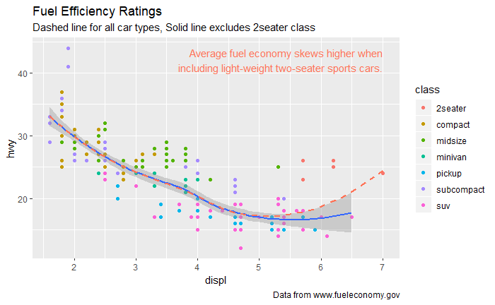

```r
ggplot(data = mpg, aes(x = displ, y = hwy)) +
  geom_point(mapping = aes(color = class)) +
  geom_text(aes(label = label_text),
            data = annotation,
            vjust = "top", hjust = "right",
            color = "coral1") +
  geom_smooth(data = mpg %>% filter(class != "2seater"),
              se = TRUE) +
  geom_smooth(data = mpg, color = "coral1", se = FALSE, linetype = 2) +
  labs(
    title = "Fuel Efficiency Ratings",
    subtitle = "Dashed line for all car types, Solid line excludes 2seater class",
    caption = "Data from www.fueleconomy.gov"
  )
```

## Themes

`theme_bw()`

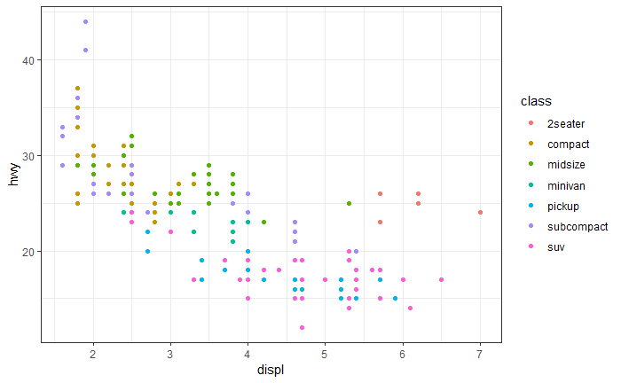

```r
hwy_plot +
  theme_bw()
```

## Saving

`ggsave()` will save your existing visualization to disk. **However**, when you compose your code using R Markdown (and `knitr`), you can knit your literate code and integrate your dynamically produced visualizations into your reports, all without separately saving your image to disk. Read more about [R Markdown](http://r4ds.had.co.nz/r-markdown.html) or browse the [R Markdown support pages](https://rmarkdown.rstudio.com/).

## Extending ggplot packages

Extra cool and special packages

- `RColorBrewer` – highly visible color palettes
- `viridis` – like `RColorBrewer`, this is a color scale tool especially tuned to visibility issues for for continuous data
- `ggrepel` – adjust labels to prevent overlap
- **Annimation**: use `gganimate`to animate plots with motion
- **Interactivity**: use `plotly` to turn your visualization into an interactive, publication-quality, online experience
- Gallery of other extra cool [ggplot extensions](http://www.ggplot2-exts.org/gallery/)

## Resources

- R for Data Science by Hadley Wickham. Chapter on *Data Visualization*, & Chapter on *Graphics for Communication*, & Chapter on *Exploratory Data Analysis*
- Intro, Tutorials, and Reference materials by Selva Prabhakaran
- ggplot cookbook
- [Data Visualization](http://socviz.co/): A practical introduction by Kieran Healy
- [Fundamentals of Data Visualization](https://serialmentor.com/dataviz/) by Claus O. Wilke

## devtools::session_info

List the packages used to develop this code

|  | setting | value |
| --- | --- | --- |
| version | version | R version 3.5.1 (2018-07-02) |
| system | system | x86_64, mingw32 |
| ui | ui | RStudio (1.1.456) |
| language | language | (EN) |
| collate | collate | English_United States.1252 |
| tz | tz | America/New_York |
| date | date | 2018-08-23 |

```
Packages ------------------------------------------------------------------------------------
```

```
 package      * version date       source
 assertthat     0.2.0   2017-04-11 CRAN (R 3.5.1)
 backports      1.1.2   2017-12-13 CRAN (R 3.5.0)
 base         * 3.5.1   2018-07-02 local
 base64enc      0.1-3   2015-07-28 CRAN (R 3.5.0)
 bindr          0.1.1   2018-03-13 CRAN (R 3.5.1)
 bindrcpp     * 0.2.2   2018-03-29 CRAN (R 3.5.1)
 broom          0.5.0   2018-07-17 CRAN (R 3.5.1)
 cellranger     1.1.0   2016-07-27 CRAN (R 3.5.1)
 class          7.3-14  2015-08-30 CRAN (R 3.5.1)
 classInt       0.2-3   2018-04-16 CRAN (R 3.5.1)
 cli            1.0.0   2017-11-05 CRAN (R 3.5.1)
 colorspace     1.3-2   2016-12-14 CRAN (R 3.5.1)
 compiler       3.5.1   2018-07-02 local
 crayon         1.3.4   2017-09-16 CRAN (R 3.5.1)
 datasets     * 3.5.1   2018-07-02 local
 DBI            1.0.0   2018-05-02 CRAN (R 3.5.1)
 devtools     * 1.13.6  2018-06-27 CRAN (R 3.5.1)
 digest         0.6.15  2018-01-28 CRAN (R 3.5.1)
 dplyr        * 0.7.6   2018-06-29 CRAN (R 3.5.1)
 e1071          1.7-0   2018-07-28 CRAN (R 3.5.1)
 evaluate       0.11    2018-07-17 CRAN (R 3.5.1)
 fansi          0.3.0   2018-08-13 CRAN (R 3.5.1)
 forcats      * 0.3.0   2018-02-19 CRAN (R 3.5.1)
 fs             1.2.5   2018-07-30 CRAN (R 3.5.1)
 ggplot2      * 3.0.0   2018-07-03 CRAN (R 3.5.1)
 glue           1.3.0   2018-07-17 CRAN (R 3.5.1)
 graphics     * 3.5.1   2018-07-02 local
 grDevices    * 3.5.1   2018-07-02 local
 grid           3.5.1   2018-07-02 local
 gridExtra      2.3     2017-09-09 CRAN (R 3.5.1)
 gtable         0.2.0   2016-02-26 CRAN (R 3.5.1)
 haven          1.1.2   2018-06-27 CRAN (R 3.5.1)
 hms            0.4.2   2018-03-10 CRAN (R 3.5.1)
 htmltools      0.3.6   2017-04-28 CRAN (R 3.5.1)
 httr           1.3.1   2017-08-20 CRAN (R 3.5.1)
 jsonlite       1.5     2017-06-01 CRAN (R 3.5.1)
 knitr          1.20    2018-02-20 CRAN (R 3.5.1)
 labeling       0.3     2014-08-23 CRAN (R 3.5.0)
 lattice        0.20-35 2017-03-25 CRAN (R 3.5.1)
```

[output cut: 28 more lines]

```
 stringr      * 1.3.1   2018-05-10 CRAN (R 3.5.1)
 tibble       * 1.4.2   2018-01-22 CRAN (R 3.5.1)
 tidyr        * 0.8.1   2018-05-18 CRAN (R 3.5.1)
 tidyselect     0.2.4   2018-02-26 CRAN (R 3.5.1)
 tidyverse    * 1.2.1   2017-11-14 CRAN (R 3.5.1)
 tools          3.5.1   2018-07-02 local
 units          0.6-0   2018-06-09 CRAN (R 3.5.1)
 usethis      * 1.4.0   2018-08-14 CRAN (R 3.5.1)
 utf8           1.1.4   2018-05-24 CRAN (R 3.5.1)
 utils        * 3.5.1   2018-07-02 local
 viridis        0.5.1   2018-03-29 CRAN (R 3.5.1)
 viridisLite    0.3.0   2018-02-01 CRAN (R 3.5.1)
 withr          2.1.2   2018-03-15 CRAN (R 3.5.1)
 xml2           1.2.0   2018-01-24 CRAN (R 3.5.1)
 yaml           2.2.0   2018-07-25 CRAN (R 3.5.1)
```

## Shareable

Shareable via Creative Commons: [CC-BY-NC](https://creativecommons.org/licenses/by-nc/4.0/) – Attribution, Non-Commercial

[figure not shown]